# Scorecard Generation

Credit Risk Intelligence Platform

Nihira Sharma

2026-06-29

```r
knitr::opts_chunk$set(echo=TRUE, message=TRUE, warning=FALSE,
                      fig.width=10, fig.height=6, results='markup')
library(tidyverse)
library(scales)
library(knitr)
source("../R/model_utils.R")   # metric functions
```

```
## Metric functions loaded
##   - compute_gini()
##   - compute_ks()
##   - compute_auc()
##   - compute_calibration()
##   - compute_lift()
##   - compute_confusion_matrix()
##   - summarise_metrics()
```

```r
source("../R/scorecard.R")     # scorecard functions

cat("Scorecard Generation - Ready\n")
```

```
## Scorecard Generation - Ready
```

```r
cat("Loaded model_utils.R and scorecard.R\n")
```

```
## Loaded model_utils.R and scorecard.R
```

## Overview

This notebook converts the production logistic regression model into an **industry-standard bin-level points scorecard** - the format lenders actually deploy.

The value of a bin-level card is auditability: a credit analyst can read a single applicant’s decision row by row - “age band gives +28, employment band gives +12, …” - and the points sum to the score. This is the artifact real risk teams sign off on.

# Section 1: Load Model, Predictions & WOE Bins

```r
model_lr  <- readRDS("../outputs/model_logistic.rds")
test_pred <- readRDS("../data/processed/test_with_predictions.rds")
woe_bins  <- readRDS("../data/processed/woe_bins.rds")

coefs <- coef(model_lr)

cat("Model loaded\n")
```

```
## Model loaded
```

```r
cat("  Coefficients:", length(coefs), "(intercept + features)\n")
```

```
##   Coefficients: 17 (intercept + features)
```

```r
cat("  Test set:", nrow(test_pred), "applicants\n")
```

```
##   Test set: 92253 applicants
```

```r
cat("  WOE bins object class:", class(woe_bins)[1], "\n\n")
```

```
##   WOE bins object class: list
```

```r
stopifnot("pred_lr" %in% names(test_pred), "target" %in% names(test_pred))

cat("Predicted probability range:",
    round(min(test_pred$pred_lr), 4), "–",
    round(max(test_pred$pred_lr), 4), "\n")
```

```
## Predicted probability range: 0.0096 – 0.3869
```

# Section 2: PDO Scaling Parameters

A scorecard maps log-odds to points with a linear transform:

$$\text{Score} = \text{Offset} +
\text{Factor} \times \ln(\text{odds}_\text{good})$$

anchored by three business choices - a **base score**, the **base odds** at that score, and **PDO** (points to double the odds). `Factor` and `Offset` are derived from these.

```r
scaling <- make_scaling(base_score = 600, base_odds = 50, pdo = 20)

cat("PDO Scaling Parameters\n")
```

```
## PDO Scaling Parameters
```

```r
cat("──────────────────────────────────────\n")
cat("  Base score:     ", scaling$base_score, "\n")
```

```
##   Base score:      600
```

```r
cat("  Base odds:      ", scaling$base_odds, ": 1 (good:bad)\n")
```

```
##   Base odds:       50 : 1 (good:bad)
```

```r
cat("  PDO:            ", scaling$pdo, "points to double odds\n\n")
```

```
##   PDO:             20 points to double odds
```

```r
cat("  Derived Factor: ", round(scaling$factor, 4), "\n")
```

```
##   Derived Factor:  28.8539
```

```r
cat("  Derived Offset: ", round(scaling$offset, 4), "\n\n")
```

```
##   Derived Offset:  487.1229
```

```r
cat("Interpretation: every", scaling$pdo, "points, the odds of being a\n")
```

```
## Interpretation: every 20 points, the odds of being a
```

```r
cat("good (non-default) applicant double.\n")
```

```
## good (non-default) applicant double.
```

```r
saveRDS(scaling, "../outputs/scorecard_scaling_params.rds")
```

# Section 3: Build the Bin-Level Points Card

For each feature and bin:

$$\text{Points} = \frac{\text{Offset} -
\text{Factor} \times \beta_0}{n} - \text{Factor} \times \beta_i \times
\text{WOE}_\text{bin}$$

The intercept is spread evenly across features so an applicant’s matched bin points sum to their total score.

```r
card <- build_scorecard(coefs, woe_bins, scaling)

base_pts <- attr(card, "base_points_per_feature")

cat("Scorecard built\n")
```

```
## Scorecard built
```

```r
cat("  Rows (feature × bin):", nrow(card), "\n")
```

```
##   Rows (feature × bin): 64
```

```r
cat("  Features in card:    ", length(unique(card$coef_name)), "\n")
```

```
##   Features in card:     16
```

```r
cat("  Base points/feature: ", round(base_pts, 1), "\n\n")
```

```
##   Base points/feature:  34.8
```

```r
cat("Sample of the points card:\n")
```

```
## Sample of the points card:
```

```r
print(head(card %>% select(variable, bin, woe, beta, points), 20))
```

```
##                            variable                    bin         woe
## 1                       amt_annuity           [44000, Inf) -0.32971477
## 2                       amt_annuity [-Inf,16000)%,%missing -0.14807732
## 3                       amt_annuity          [36000,44000) -0.02574427
## 4                       amt_annuity          [16000,36000)  0.12040854
## 5                        amt_credit         [1350000, Inf) -0.66015615
## 6                        amt_credit          [-Inf,150000) -0.31567644
## 7                        amt_credit       [900000,1350000) -0.22333431
## 8                        amt_credit        [650000,900000) -0.05809180
## 9                        amt_credit        [150000,300000) -0.02978131
## 10                       amt_credit        [300000,650000)  0.24944019
## 11                 amt_income_total          [310000, Inf) -0.33284710
## 12                 amt_income_total        [230000,310000) -0.14719876
## 13                 amt_income_total        [220000,230000) -0.06892012
## 14                 amt_income_total          [-Inf,220000)  0.04621062
```

[output cut: 27 more lines]

```r
write_csv(card, "../outputs/scorecard_points_card.csv")
cat("\nSaved outputs/scorecard_points_card.csv\n")
```

```
##
## Saved outputs/scorecard_points_card.csv
```

## Points Range by Feature

How much each feature can swing an applicant’s score - the spread between its lowest- and highest-points bins. Wider bars are the most influential features.

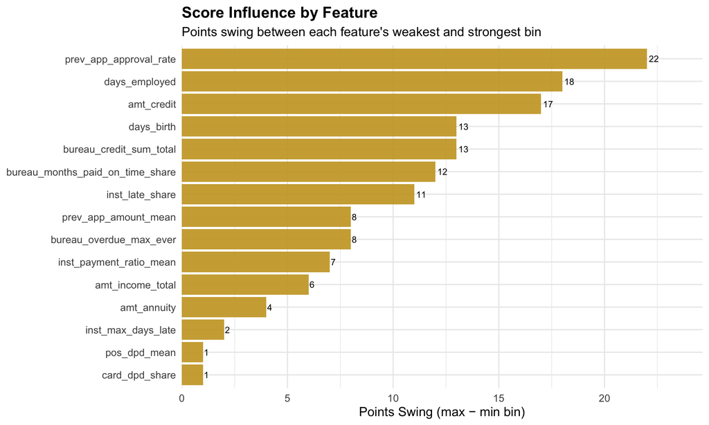

```r
feature_swing <- card %>%
  group_by(variable) %>%
  summarise(
    min_points = min(points),
    max_points = max(points),
    swing = max(points) - min(points),
    .groups = "drop"
  ) %>%
  arrange(desc(swing)) %>%
  slice_head(n = 15)

ggplot(feature_swing, aes(x = reorder(variable, swing), y = swing)) +
  geom_col(fill = "#C9A227", alpha = 0.9) +
  geom_text(aes(label = swing), hjust = -0.2, size = 3.2) +
  coord_flip() +
  scale_y_continuous(expand = expansion(mult = c(0, 0.12))) +
  labs(
    title = "Score Influence by Feature",
    subtitle = "Points swing between each feature's weakest and strongest bin",
    x = NULL, y = "Points Swing (max − min bin)"
  ) +
  theme_minimal(base_size = 13) +
  theme(plot.title = element_text(face = "bold"))
```

# Section 4: Score the Test Population

Because the test set already holds WOE values, scoring is a direct, exact transform of the model logit (guaranteed identical to summing card points).

```r
test_scored <- test_pred %>%
  mutate(score = score_from_woe(., coefs, scaling))

cat("Score Distribution (Test Set)\n")
```

```
## Score Distribution (Test Set)
```

```r
cat("──────────────────────────────────────\n")
cat("  Min:   ", min(test_scored$score), "\n")
```

```
##   Min:    500
```

```r
cat("  Q1:    ", round(quantile(test_scored$score, 0.25)), "\n")
```

```
##   Q1:     550
```

```r
cat("  Median:", round(median(test_scored$score)), "\n")
```

```
##   Median: 561
```

```r
cat("  Mean:  ", round(mean(test_scored$score)), "\n")
```

```
##   Mean:   561
```

```r
cat("  Q3:    ", round(quantile(test_scored$score, 0.75)), "\n")
```

```
##   Q3:     573
```

```r
cat("  Max:   ", max(test_scored$score), "\n\n")
```

```
##   Max:    621
```

```r
cor_check <- cor(test_scored$score, test_scored$pred_lr)
cat("Correlation(score, P(default)):", round(cor_check, 4), "\n")
```

```
## Correlation(score, P(default)): -0.9552
```

```r
cat("(Should be strongly negative - higher score = lower risk)\n")
```

```
## (Should be strongly negative - higher score = lower risk)
```

## Score Distribution

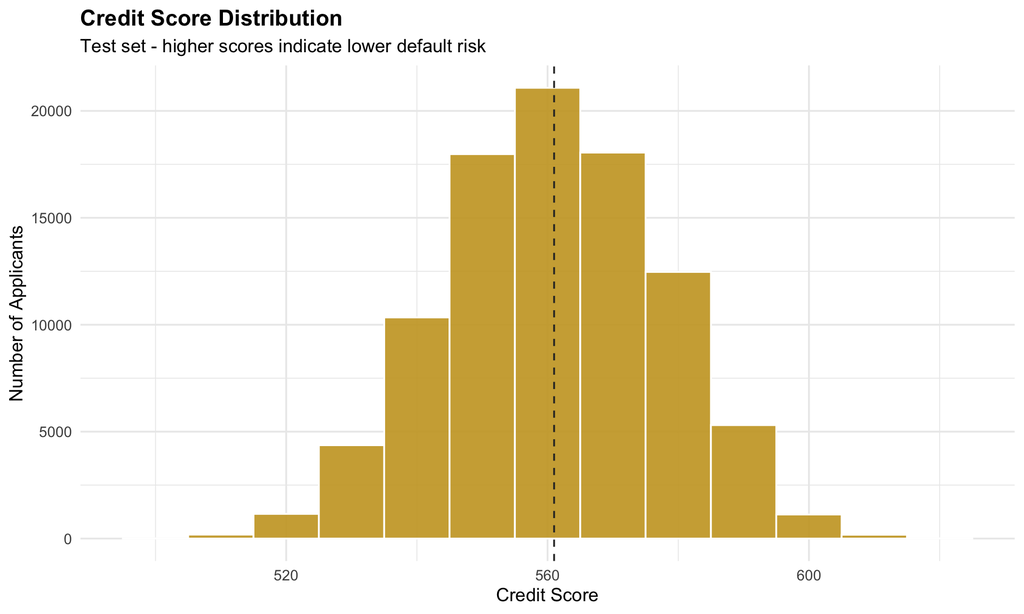

```r
ggplot(test_scored, aes(x = score)) +
  geom_histogram(binwidth = 10, fill = "#C9A227", colour = "white", alpha = 0.9) +
  geom_vline(aes(xintercept = median(score)), linetype = "dashed", colour = "#2E2E2E") +
  labs(
    title = "Credit Score Distribution",
    subtitle = "Test set - higher scores indicate lower default risk",
    x = "Credit Score", y = "Number of Applicants"
  ) +
  theme_minimal(base_size = 13) +
  theme(plot.title = element_text(face = "bold"))
```

## Score vs. Observed Default Rate

The key validation chart: as scores rise, the actual default rate must fall monotonically.

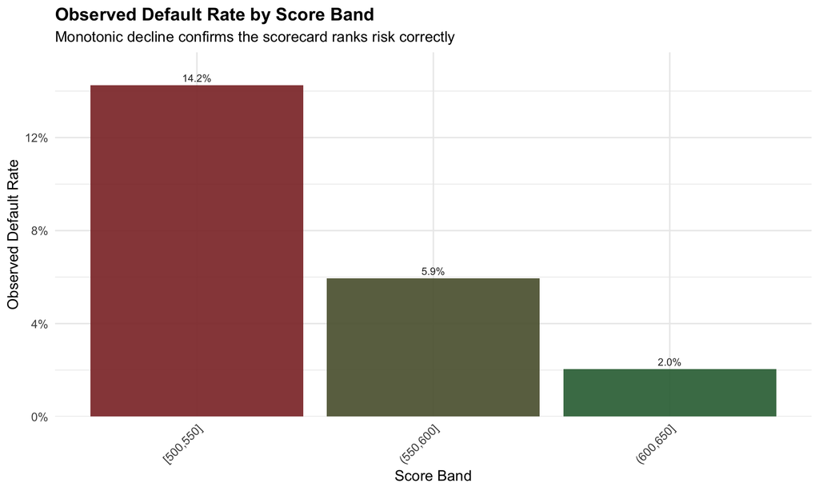

```r
score_bands_check <- test_scored %>%
  mutate(score_band = cut(score,
                          breaks = seq(floor(min(score)/50)*50,
                                       ceiling(max(score)/50)*50, by = 50),
                          include.lowest = TRUE)) %>%
  group_by(score_band) %>%
  summarise(n = n(), default_rate = mean(target), .groups = "drop") %>%
  filter(n >= 30)

ggplot(score_bands_check, aes(x = score_band, y = default_rate, fill = default_rate)) +
  geom_col(alpha = 0.9) +
  geom_text(aes(label = percent(default_rate, accuracy = 0.1)),
            vjust = -0.5, size = 3.2, colour = "#2E2E2E") +
  scale_fill_gradient(low = "#2E6B3E", high = "#8B2E2E", guide = "none") +
  scale_y_continuous(labels = percent_format(), expand = expansion(mult = c(0, 0.1))) +
  labs(
    title = "Observed Default Rate by Score Band",
    subtitle = "Monotonic decline confirms the scorecard ranks risk correctly",
    x = "Score Band", y = "Observed Default Rate"
  ) +
  theme_minimal(base_size = 13) +
  theme(plot.title = element_text(face = "bold"),
        axis.text.x = element_text(angle = 45, hjust = 1))
```

# Section 5: Decision Cutoffs (Approve / Review / Decline)

Cutoffs convert the continuous score into an actionable decision. Adjust `decline_cut` / `approve_cut` after seeing your score distribution above so the approved band lands at a default rate you accept.

```r
# Cutoffs are calibrated to THIS model's score range (≈500–621)
# Scores compress because Gini ≈ 0.31; we split on the actual distribution,
# not a generic 300–850 assumption. Tune these to your risk appetite
decline_cut <- 545   # below this: DECLINE
approve_cut <- 575   # at/above this: APPROVE; between: REVIEW

test_decisions <- test_scored %>%
  mutate(decision = assign_decision(score, decline_cut, approve_cut))

decision_summary <- test_decisions %>%
  group_by(decision) %>%
  summarise(
    n_applicants = n(),
    pct_population = n() / nrow(test_decisions),
    n_defaults = sum(target),
    default_rate = mean(target),
    .groups = "drop"
  ) %>%
  mutate(
    pct_population = round(pct_population, 4),
    default_rate = round(default_rate, 4),
    pct_of_all_defaults = round(n_defaults / sum(n_defaults), 4)
  )

cat("Decision Band Summary\n")
```

```
## Decision Band Summary
```

```r
cat("──────────────────────────────────────\n")
cat("  Decline: score <", decline_cut, "\n")
```

```
##   Decline: score < 545
```

```r
cat("  Approve: score >=", approve_cut, "\n")
```

```
##   Approve: score >= 575
```

```r
cat("  Review: ", decline_cut, "–", approve_cut - 1, "\n\n")
```

```
##   Review:  545 – 574
```

```r
print(decision_summary)
```

```
## # A tibble: 3 × 6
##   decision n_applicants pct_population n_defaults default_rate
##   <fct>           <int>          <dbl>      <dbl>        <dbl>
## 1 DECLINE         14726          0.160       2389       0.162
## 2 REVIEW          56921          0.617       4336       0.0762
## 3 APPROVE         20606          0.223        749       0.0363
## # ℹ 1 more variable: pct_of_all_defaults <dbl>
```

```r
approve_band <- decision_summary %>% filter(decision == "APPROVE")
decline_band <- decision_summary %>% filter(decision == "DECLINE")

cat("\nBusiness Read-out:\n")
```

```
##
## Business Read-out:
```

```r
cat("  Auto-approve rate:    ", percent(approve_band$pct_population, 0.1), "\n")
```

```
##   Auto-approve rate:     22.3%
```

```r
cat("  Approved default rate:", percent(approve_band$default_rate, 0.01),
    "(vs", percent(mean(test_decisions$target), 0.01), "overall)\n")
```

```
##   Approved default rate: 3.63% (vs 8.10% overall)
```

```r
cat("  Declined band catches:", percent(decline_band$pct_of_all_defaults, 0.1),
    "of all defaults\n")
```

```
##   Declined band catches: 32.0% of all defaults
```

```r
write_csv(decision_summary, "../outputs/scorecard_decision_summary.csv")
cat("\nSaved outputs/scorecard_decision_summary.csv\n")
```

```
##
## Saved outputs/scorecard_decision_summary.csv
```

## Decision Bands Visualised

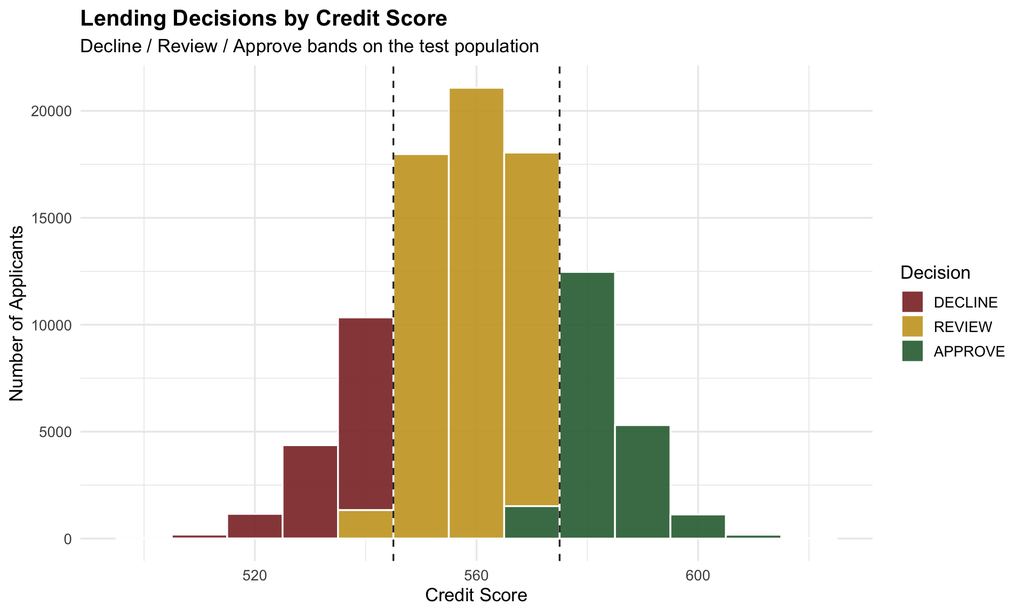

```r
ggplot(test_decisions, aes(x = score, fill = decision)) +
  geom_histogram(binwidth = 10, colour = "white", alpha = 0.9) +
  geom_vline(xintercept = c(decline_cut, approve_cut),
             linetype = "dashed", colour = "#2E2E2E") +
  scale_fill_manual(values = c("DECLINE" = "#8B2E2E",
                               "REVIEW"  = "#C9A227",
                               "APPROVE" = "#2E6B3E")) +
  labs(
    title = "Lending Decisions by Credit Score",
    subtitle = "Decline / Review / Approve bands on the test population",
    x = "Credit Score", y = "Number of Applicants", fill = "Decision"
  ) +
  theme_minimal(base_size = 13) +
  theme(plot.title = element_text(face = "bold"))
```

# Section 6: Score Band Reference Table

The day-to-day lookup a risk team uses: each band with population share, default rate, and recommended action.

```r
score_band_table <- test_decisions %>%
  mutate(band = cut(score,
                    breaks = c(-Inf, 520, 540, 555, 570, 585, 600, Inf),
                    labels = c("<520", "520–539", "540–554", "555–569",
                               "570–584", "585–599", "600+"))) %>%
  group_by(band) %>%
  summarise(n = n(),
            pct_population = n() / nrow(test_decisions),
            default_rate = mean(target),
            .groups = "drop") %>%
  mutate(
    cumulative_pct = cumsum(n) / sum(n),
    recommended_action = case_when(
      default_rate >= 0.12 ~ "DECLINE",
      default_rate >= 0.05 ~ "REVIEW",
      TRUE                 ~ "APPROVE"
    ),
    pct_population = percent(pct_population, 0.1),
    default_rate = percent(default_rate, 0.01),
    cumulative_pct = percent(cumulative_pct, 0.1)
  )

cat("Score Band Reference Table\n\n")
```

```
## Score Band Reference Table
```

```r
print(score_band_table)
```

```
## # A tibble: 7 × 6
##   band        n pct_population default_rate cumulative_pct recommended_action
##   <fct>   <int> <chr>          <chr>        <chr>          <chr>
## 1 <520      558 0.6%           26.52%       0.6%           DECLINE
## 2 520–539  9484 10.3%          16.94%       10.9%          DECLINE
## 3 540–554 23991 26.0%          10.56%       36.9%          REVIEW
## 4 555–569 30697 33.3%          6.81%        70.2%          REVIEW
## 5 570–584 20902 22.7%          4.18%        92.8%          APPROVE
## 6 585–599  6080 6.6%           3.45%        99.4%          APPROVE
## 7 600+      541 0.6%           2.03%        100.0%         APPROVE
```

```r
write_csv(score_band_table, "../outputs/scorecard_band_reference.csv")
cat("\nSaved outputs/scorecard_band_reference.csv\n")
```

```
##
## Saved outputs/scorecard_band_reference.csv
```

# Section 7: Validate the Scorecard Preserves Model Performance

```r
# Higher score = lower risk, so rank on NEGATIVE score for the metric helpers.
gini_score <- compute_gini(test_scored$target, -test_scored$score)
ks_score   <- compute_ks(test_scored$target, -test_scored$score)
auc_score  <- compute_auc(test_scored$target, -test_scored$score)

gini_model <- compute_gini(test_scored$target, test_scored$pred_lr)
ks_model   <- compute_ks(test_scored$target, test_scored$pred_lr)
auc_model  <- compute_auc(test_scored$target, test_scored$pred_lr)

validation <- tibble(
  Metric = c("Gini", "KS", "AUC"),
  `From Model (prob)` = round(c(gini_model, ks_model, auc_model), 4),
  `From Scorecard`    = round(c(gini_score, ks_score, auc_score), 4),
  Difference          = round(c(gini_score - gini_model,
                                ks_score - ks_model,
                                auc_score - auc_model), 6)
)

cat("Scorecard vs. Model - Ranking Power\n")
```

```
## Scorecard vs. Model - Ranking Power
```

```r
cat("──────────────────────────────────────\n")
print(validation)
```

```
## # A tibble: 3 × 4
##   Metric `From Model (prob)` `From Scorecard` Difference
##   <chr>                <dbl>            <dbl>      <dbl>
## 1 Gini                 0.313            0.312  -0.000073
## 2 KS                   0.227            0.225  -0.00202
## 3 AUC                  0.656            0.656  -0.000036
```

```r
if (all(abs(validation$Difference) < 0.001)) {
  cat("\nScorecard preserves model performance (differences ≈ 0)\n")
  cat("  The points scaling is a faithful monotonic transform.\n")
} else {
  cat("\nScorecard metrics differ from model - check scaling.\n")
}
```

```
##
## Scorecard metrics differ from model - check scaling.
```

```r
write_csv(validation, "../outputs/scorecard_validation.csv")
```

# Section 8: Save Scorecard Artifacts

```r
test_scored_out <- test_decisions %>%
  select(SK_ID_CURR, target, pred_lr, score, decision)

saveRDS(test_scored_out, "../data/processed/test_scored.rds")
write_csv(test_scored_out, "../scorecard_output/test_scored.csv")

# Self-contained, deployable scorecard object for the dashboard
scorecard_obj <- list(
  scaling        = scaling,
  card           = card,
  cutoffs        = list(decline = decline_cut, approve = approve_cut),
  band_reference = score_band_table,
  validation     = validation,
  model_coefs    = coefs
)
saveRDS(scorecard_obj, "../outputs/scorecard.rds")

cat("\nScorecard artifacts saved\n")
```

```
##
## Scorecard artifacts saved
```

```r
cat("  - outputs/scorecard.rds (deployable scorecard object)\n")
```

```
##   - outputs/scorecard.rds (deployable scorecard object)
```

```r
cat("  - outputs/scorecard_points_card.csv (the bin-level card)\n")
```

```
##   - outputs/scorecard_points_card.csv (the bin-level card)
```

```r
cat("  - outputs/scorecard_scaling_params.rds\n")
```

```
##   - outputs/scorecard_scaling_params.rds
```

```r
cat("  - outputs/scorecard_decision_summary.csv\n")
```

```
##   - outputs/scorecard_decision_summary.csv
```

```r
cat("  - outputs/scorecard_band_reference.csv\n")
```

```
##   - outputs/scorecard_band_reference.csv
```

```r
cat("  - outputs/scorecard_validation.csv\n")
```

```
##   - outputs/scorecard_validation.csv
```

```r
cat("  - data/processed/test_scored.rds\n")
```

```
##   - data/processed/test_scored.rds
```

```r
cat("  - scorecard_output/test_scored.csv\n")
```

```
##   - scorecard_output/test_scored.csv
```

# Summary

The scorecard object (`outputs/scorecard.rds`) is ready for the interactive dashboard, where a user can score a hypothetical applicant and see the points breakdown.